# Project 2 – Geospatial Mapping & Webscraping

Brennan Black

2021-04-07

```r
library(tidyverse)
library(rvest)
library(robotstxt)
library(knitr)
library(ggmap)
```

```r
library(maps)
library(zoo)
library(lubridate)
library(knitr)
library(kableExtra)
library(gridExtra)
options(scipen = 999)
```

```r
paths_allowed("https://www.ratebeer.com/")
```

```
##
 www.ratebeer.com
```

```
## [1] TRUE
```

```r
nc_producers <- "https://www.ratebeer.com/breweries/unitedstates/33/213/"

ca_producers <- "https://www.ratebeer.com/breweries/unitedstates/5/213/"

ma_producers <- "https://www.ratebeer.com/breweries/unitedstates/21/213/"

va_producers <- "https://www.ratebeer.com/breweries/unitedstates/46/213/"

wy_producers <- "https://www.ratebeer.com/breweries/unitedstates/51/213/"
```

These are all of the urls that we will be scraping for this project. I have labeled them based off of which state’s data they have.

# Question 1

```r
scrape_url <- function(x) {
  urls <- x %>%
    read_html() %>%
    html_nodes(".inactive a") %>%
    html_attr("href") %>%
    paste("http://www.ratebeer.com", .,sep = "")

  for (i in 1:3) {
      check_url<- read_html(urls[i]) %>%
      html_nodes("#brewerTable a:nth-child(1)") %>%
      html_text()

  if (length(check_url) == 0) {
    urls <- urls[-i]
  }
  }

  return(urls)
}
```

This function, which I named scrape_url, takes the state url as an input and outputs the meadery, cidery, and sake producer urls for that respective state. It does this by taking the meadery, cidery, and sake producer specific node (which is called “.inactive a”) and combines it with “http://www.ratebeer.com” in order to form three complete urls.

However, not all states have any producers listed on their meadery, cidery, or sake producer pages. Therefore, I used a for loop to look through each url and put any names of producers (using the “#brewerTable a:nth-child(1)” node) into a vector called check_url. Then, I used an if statement to decide whether to keep the url based off whether the length of check_url was zero. If it was zero, this meant that there were no producers and the statement would therefore remove that url.

```r
nc_urls <- scrape_url(nc_producers)
wy_urls <- scrape_url(wy_producers)
```

# Question 2

```r
scrape_beverage_producer <- function(x) {
  #1.a: Get name of beverage producer
  beverage_producer <- x %>%
    read_html() %>%
    html_nodes("#brewerTable a:nth-child(1)") %>%
    html_text()

  #1.b: Get active producer city names
  active_cities <- x %>%
    read_html() %>%
    html_nodes(".filter") %>%
    html_text()

  #1.b1: Get closed producer city names
  closed_cities <- x %>%
    read_html() %>%
    html_nodes("#brewerTable span") %>%
    html_text()

  cities <- c(active_cities, closed_cities)

  #1.c: Get type of establishment
  types <- x %>%
    read_html() %>%
    html_nodes("td.hidden-xs.hidden-sm") %>%
    html_text()

  #1.d: Get the beverage counts
  counts <- x %>%
    read_html() %>%
    html_nodes(".hidden-sm+ td") %>%
    html_text() %>%
    str_trim() %>%
    as.numeric()

  #1.e: Get the year in which it was established
  ests <- x %>%
    read_html() %>%
    html_nodes("td:nth-child(5)") %>%
    html_text() %>%
    as.numeric()

  #1.f: Get the status (active or closed)
  status_active <- rep("Active", length(active_cities))

  status_closed <- rep("Closed", length(closed_cities))

  status <- c(status_active, status_closed)

  #Create the data frame
  state_beverage_producers <- tibble(
    name = beverage_producer,
    city = cities,
    type = types,
    beverage_count = counts,
    est = ests,
    status = status
)
}
```

This function, which I named scape_beverage_producer, takes the urls that were output by the scrape_url function as its input. It gets the producer names, the cities that they are in, the type of alcohol they produce, the amount of beverages they make, the year they were established, and whether they are active or closed. Finally, it creates a dataframe of all of this data.

### North Carolina Mead Producers

```r
nc_mead <- scrape_beverage_producer(nc_urls[1])

nc_mead %>%
  head(10)
```

```
## # A tibble: 7 x 6
##   name                    city             type    beverage_count   est status
##   <chr>                   <chr>            <chr>            <dbl> <dbl> <chr>
## 1 " Bee & Bramble"        "Fairview"       Meadery              7  2015 Active
## 2 " Desis Dew Meadery"    " Rougemont"     Meadery              5  2004 Active
## 3 " Fox Hill Meadery"     "Marshall"       Meadery              7  2008 Active
## 4 " Honeygirl Meadery"    "Durham"         Meadery             15  2017 Active
## 5 " Keeper's Cut Meadery" "Marion"         Meadery              1  2019 Active
## 6 " Starrlight Mead"      "Pittsboro"      Meadery             35  2011 Active
## 7 " World’s Edge Meadery" "Hendersonville" Meadery              1  2019 Active
```

### North Carolina Cider Producers

```r
nc_cider <- scrape_beverage_producer(nc_urls[2])

nc_cider %>%
  head(10)
```

```
## # A tibble: 10 x 6
##    name                        city            type  beverage_count   est status
##    <chr>                       <chr>           <chr>          <dbl> <dbl> <chr>
##  1 " Barn Door Ciderworks"     "Fletcher"      Cide…              9  2021 Active
##  2 " Black Mountain Ciderwork… "Black Mountai… Cide…             53  2014 Active
##  3 " Blackwater Cider"         "Windsor"       Cide…              9  2017 Active
##  4 " Botanist and Barrel"      "Cedar Grove "  Cide…             49  2017 Active
##  5 " Bull City Ciderworks"     "Durham"        Cide…             44  2014 Active
##  6 " Chatham Cider Works"      "Pittsboro"     Cide…              4  2018 Active
##  7 " Daidala Ciders"           "Asheville"     Cide…              9  2018 Active
##  8 " Fishing Creek Hard Cider" "Whitakers"     Cide…              1  2018 Active
##  9 " Flat Rock Cider Company"  "Flat Rock"     Cide…              6  2018 Active
## 10 " GoodRoad CiderWorks"      "Charlotte"     Cide…             53  2017 Active
```

### North Carolina Sake Producers

```r
nc_sake <- scrape_beverage_producer(nc_urls[3])

nc_sake %>%
  head(10)
```

```
## # A tibble: 2 x 6
##   name                       city      type          beverage_count   est status
##   <chr>                      <chr>     <chr>                  <dbl> <dbl> <chr>
## 1 " Ben's American Sake"     Asheville Sake Producer             15  2015 Active
## 2 " Blue Kudzu Sake Company" Asheville Sake Producer              1  2014 Closed
```

# Question 3

### Wyoming Mead Producers

```r
wy_mead <- scrape_beverage_producer(wy_urls[1])

wy_mead %>%
  head(10)
```

```
## # A tibble: 2 x 6
##   name                        city     type    beverage_count   est status
##   <chr>                       <chr>    <chr>            <dbl> <dbl> <chr>
## 1 " Big Lost Meadery"         Gillette Meadery             19  2014 Active
## 2 " Table Mountain Vineyards" Huntley  Meadery              2  2009 Active
```

### Wyoming Cider Producers

```r
wy_cider <- scrape_beverage_producer(wy_urls[2])

wy_cider %>%
  head(10)
```

```
## # A tibble: 1 x 6
##   name                 city    type   beverage_count   est status
##   <chr>                <chr>   <chr>           <dbl> <dbl> <chr>
## 1 " Farmstead Wyoming" Jackson Cidery              1  2020 Active
```

### Wyoming Sake Producers

```r
#wy_sake <- scrape_beverage_producer(wy_urls[3])

#wy_sake %>%
#  head(10)
```

This code will not run because Wyoming does not have any sake producers.

# Question 4

```r
ca_urls <- scrape_url(ca_producers)
ma_urls <- scrape_url(ma_producers)
va_urls <- scrape_url(va_producers)
```

### North Carolina Beverage Producers

```r
nc_beverages <- map_df(nc_urls, scrape_beverage_producer)

nc_beverages %>%
  head(15)
```

```
## # A tibble: 15 x 6
##    name                       city            type   beverage_count   est status
##    <chr>                      <chr>           <chr>           <dbl> <dbl> <chr>
##  1 " Bee & Bramble"           "Fairview"      Meade…              7  2015 Active
##  2 " Desis Dew Meadery"       " Rougemont"    Meade…              5  2004 Active
##  3 " Fox Hill Meadery"        "Marshall"      Meade…              7  2008 Active
##  4 " Honeygirl Meadery"       "Durham"        Meade…             15  2017 Active
##  5 " Keeper's Cut Meadery"    "Marion"        Meade…              1  2019 Active
##  6 " Starrlight Mead"         "Pittsboro"     Meade…             35  2011 Active
##  7 " World’s Edge Meadery"    "Hendersonvill… Meade…              1  2019 Active
##  8 " Barn Door Ciderworks"    "Fletcher"      Cidery              9  2021 Active
##  9 " Black Mountain Ciderwor… "Black Mountai… Cidery             53  2014 Active
## 10 " Blackwater Cider"        "Windsor"       Cidery              9  2017 Active
## 11 " Botanist and Barrel"     "Cedar Grove "  Cidery             49  2017 Active
## 12 " Bull City Ciderworks"    "Durham"        Cidery             44  2014 Active
## 13 " Chatham Cider Works"     "Pittsboro"     Cidery              4  2018 Active
## 14 " Daidala Ciders"          "Asheville"     Cidery              9  2018 Active
## 15 " Fishing Creek Hard Cide… "Whitakers"     Cidery              1  2018 Active
```

### California Beverage Producers

```r
ca_beverages <- map_df(ca_urls, scrape_beverage_producer)

ca_beverages %>%
  head(15)
```

```
## # A tibble: 15 x 6
##    name                       city            type   beverage_count   est status
##    <chr>                      <chr>           <chr>           <dbl> <dbl> <chr>
##  1 " Beekman & Beekman"       Hughson         Meade…              3  2009 Active
##  2 " Bjorn Mead"              Waterford       Meade…              3  2013 Active
##  3 " Bronto Mead"             San Diego       Meade…              5  2017 Active
##  4 " Chaucer's Winery"        Soquel          Meade…              3  1933 Active
##  5 " Elsa Wine & Mead"        Orange          Meade…              4  2007 Active
##  6 " Enat Tej Winery"         Oakland         Meade…              2  2009 Active
##  7 " Golden Coast Mead"       Oceanside       Meade…             28  2011 Active
##  8 " Heidrun Meadery"         Point Reyes St… Meade…             15  2006 Active
##  9 " Honey Pot Meadery"       Anaheim         Meade…              4  2016 Active
## 10 " Honeyrun Winery & Honey… Chico           Meade…              6  2006 Active
## 11 " Lost Cause Meadery"      San Diego       Meade…             41  2017 Active
## 12 " Mead Kitchen"            Berkeley        Meade…              6  2014 Active
## 13 " Meadiocrity Mead"        San Marcos      Meade…              3  2016 Active
## 14 " Rabbits Foot Meadery"    Sunnyvale       Meade…             21  2004 Active
## 15 " San Francisco Mead Comp… San Francisco   Meade…             14  2014 Active
```

### Massachusetts Beverage Producers

```r
ma_beverages <- map_df(ma_urls, scrape_beverage_producer)

ma_beverages %>%
  head(15)
```

```
## # A tibble: 15 x 6
##    name                             city      type   beverage_count   est status
##    <chr>                            <chr>     <chr>           <dbl> <dbl> <chr>
##  1 " 1634 Meadery"                  Ipswich   Meade…             14  2015 Active
##  2 " Crave Mead"                    Blacksto… Meade…             13  2016 Active
##  3 " Green River Ambrosia"          Greenfie… Meade…             11  2009 Active
##  4 " House Bear Brewing"            Newburyp… Meade…              6  2014 Active
##  5 " Isaaks of Salem"               Salem     Meade…              3  2011 Active
##  6 " Nashoba Valley Winery / Bolto… Bolton    Meade…             46  2003 Active
##  7 " Artifact Cider Project"        Springfi… Cidery             11  2015 Active
##  8 " Bantam Cider Company"          Cambridge Cidery             13  2012 Active
##  9 " Carlson Orchards"              Harvard   Cidery              1  2019 Active
## 10 " Carr's Ciderhouse"             Hadley    Cidery              5  2017 Active
## 11 " Downeast Cider House"          East Bos… Cidery             22  2011 Active
## 12 " Far From the Tree Cider"       Salem     Cidery             18  2015 Active
## 13 " Furnace Brook Winery"          Richmond  Cidery              4  2008 Active
## 14 " Harvard Cider Company"         Harvard   Cidery              6  2015 Active
## 15 " Headwater Cider Company"       Hawley    Cidery              3  2010 Active
```

### Virginia Beverage Producers

```r
va_beverages <- map_df(va_urls, scrape_beverage_producer)

va_beverages %>%
  head(15)
```

```
## # A tibble: 15 x 6
##    name                        city           type   beverage_count   est status
##    <chr>                       <chr>          <chr>           <dbl> <dbl> <chr>
##  1 " Black Heath Meadery"      Richmond       Meade…             52  2015 Active
##  2 " Blacksnake Meadery"       Dugspur        Meade…             16  2009 Active
##  3 " Capital Hive Meadery"     Ashburn        Meade…              4  2020 Active
##  4 " Haley's Honey Meadery"    Hopewell       Meade…              8  2018 Active
##  5 " Hill Top Berry Farm & Wi… Nellysford     Meade…             24  2008 Active
##  6 " Honey Grail"              Leesburg       Meade…              2  2014 Active
##  7 " Maidstone Meadery"        Delaplane      Meade…              4  2016 Active
##  8 " Melo Lion Meadery"        Yorktown       Meade…             13  2017 Active
##  9 " Misty Mountain Meadworks" Winchester     Meade…              4  2006 Active
## 10 " Saga Meadery"             Madison Heigh… Meade…              9  2016 Active
## 11 " Silver Hand Meadery"      Williamsburg   Meade…             14  2017 Active
## 12 " Skjald Meadworks"         Charlottesvil… Meade…              8  2016 Active
## 13 " Stone House Meadery"      Purcellville   Meade…              3  2017 Active
## 14 " The Thistle & Stag Meade… Fork Union     Meade…              5  2017 Active
## 15 " De Rustica Meadery"       Jeffersonton   Meade…              6  2013 Closed
```

### Wyoming Beverage Producers

```r
wy_beverages <- map_df(wy_urls, scrape_beverage_producer)

wy_beverages %>%
  head(15)
```

```
## # A tibble: 3 x 6
##   name                        city     type    beverage_count   est status
##   <chr>                       <chr>    <chr>            <dbl> <dbl> <chr>
## 1 " Big Lost Meadery"         Gillette Meadery             19  2014 Active
## 2 " Table Mountain Vineyards" Huntley  Meadery              2  2009 Active
## 3 " Farmstead Wyoming"        Jackson  Cidery               1  2020 Active
```

In the code chunks above, I used the map_df() function to have the scrape_beverage_producer function scrape through all of the urls for each state and create a dataframe for that state. I created data frames for North Carolina, California, Massachusetts, Virginia, and Wyoming. I did this in order to test the two functions and all of the possible exceptions (such as whether there are no producers of a certain type in a state or whether there are no active or closed producers in that state.)

# Question 5

```r
register_google(key = "AIzaSyB14h_szuys3SaTv1WTaJ2WEDfGDN0sl-A")
has_google_key()
```

```
## [1] TRUE
```

### California Data Wrangling

```r
ca_beverages <- ca_beverages[c(-60, -80),]
```

I took out these two rows because they were missing data for the city column, which I need for my visualizations later.

```r
ca_city_state_lon_lat <- ca_beverages %>%
  add_column(state = "California") %>%
  distinct(city, state, type) %>%
  mutate(city_state = paste(city, state, sep = ", ")) %>%
  mutate_geocode(city_state)

ca_city_count <- ca_beverages %>%
  group_by(city) %>%
  summarise(count = n())

ca_data <- ca_city_count %>%
  inner_join(ca_city_state_lon_lat) %>%
  select(-state, -city_state)
```

```r
write.csv(ca_data, "ca_beverages_geo.csv")
```

```r
ca_mapping_data <- read.csv("data/ca_beverages_geo.csv")

ca_mapping_data %>%
  head(10)
```

```
##     X        city count          type       lon      lat
## 1   1     Anaheim     1       Meadery -117.9143 33.83659
## 2   2       Aptos     1        Cidery -121.8994 36.97717
## 3   3      Auburn     1        Cidery -121.0769 38.89657
## 4   4    Berkeley     2       Meadery -122.2730 37.87152
## 5   5    Berkeley     2 Sake Producer -122.2730 37.87152
## 6   6   Berkeley      1        Cidery -122.2730 37.87152
## 7   7   Boonville     1        Cidery -123.3672 39.00897
## 8   8     Bradley     1        Cidery -120.8007 35.86330
## 9   9 Carpinteria     1       Meadery -119.5185 34.39888
## 10 10      Carson     1        Cidery -118.2817 33.83167
```

In the second chunk, I created a dataframe called ca_city_count, which contains the number of producers in each city. I did this by using grouping by city and then counting the number of types.

After all of that, I created a csv file from the ca_data dataframe and set the chunks above to eval = FALSE, which means that they will appear in the knitted file but not run. I did this because otherwise it would use ton of RAM to get the longitude and latitude data every time I knit this document. I loaded the csv file that I created and created the dataframes ca_mapping_data from it to use for geospatial mapping.

### North Carolina Data Wrangling

```r
nc_city_state_lon_lat <- nc_beverages %>%
  add_column(state = "North Carolina") %>%
  distinct(city, state, type) %>%
  mutate(city_state = paste(city, state, sep = ", ")) %>%
  mutate_geocode(city_state)

nc_city_count <- nc_beverages %>%
  group_by(city) %>%
  summarise(count = n())

nc_data <- nc_city_count %>%
  inner_join(nc_city_state_lon_lat) %>%
  select(-state, -city_state)
```

```r
write.csv(nc_data, "nc_beverages_geo.csv")
```

```r
nc_mapping_data <- read.csv("data/nc_beverages_geo.csv")

nc_mapping_data %>%
  head(10)
```

```
##     X           city count          type       lon      lat
## 1   1      Rougemont     1       Meadery -78.92640 36.21848
## 2   2      Asheville     4        Cidery -82.55149 35.59506
## 3   3      Asheville     4 Sake Producer -82.55149 35.59506
## 4   4 Black Mountain     1        Cidery -82.32123 35.61790
## 5   5        Cameron     1        Cidery -79.25530 35.32682
## 6   6   Cedar Grove      1        Cidery -79.16779 36.16764
## 7   7      Charlotte     3        Cidery -80.84313 35.22709
## 8   8         Durham     2       Meadery -78.89862 35.99403
## 9   9         Durham     2        Cidery -78.89862 35.99403
## 10 10       Fairview     1       Meadery -82.39595 35.51401
```

The code chunks above are the same as the ones for California, except the data is for North Carolina.

# Question 6

### Map of California

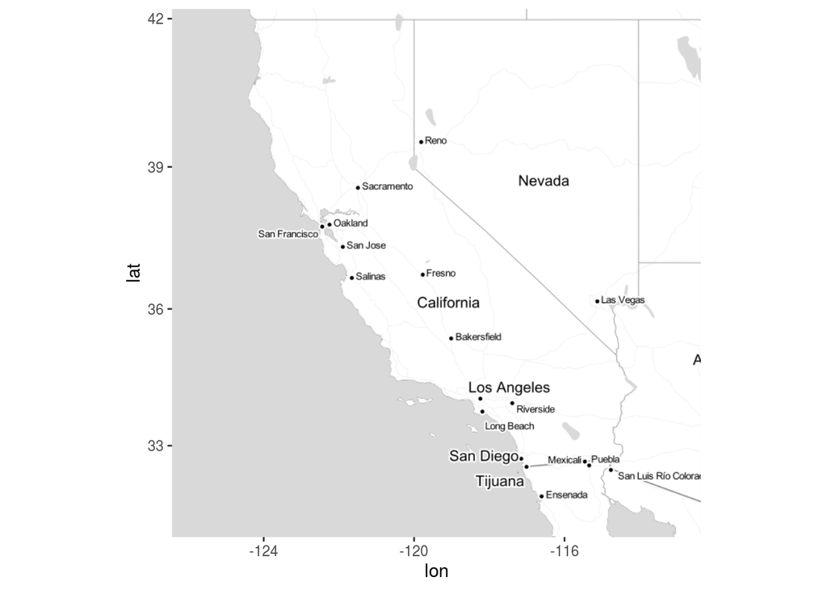

```r
ca <- get_map(location = 'California', zoom = 6, source = "stamen", maptype = "toner-lite")
ggmap(ca)
```

I created a map of California using the get_map function and I named the map ca.

### Map of North Carolina

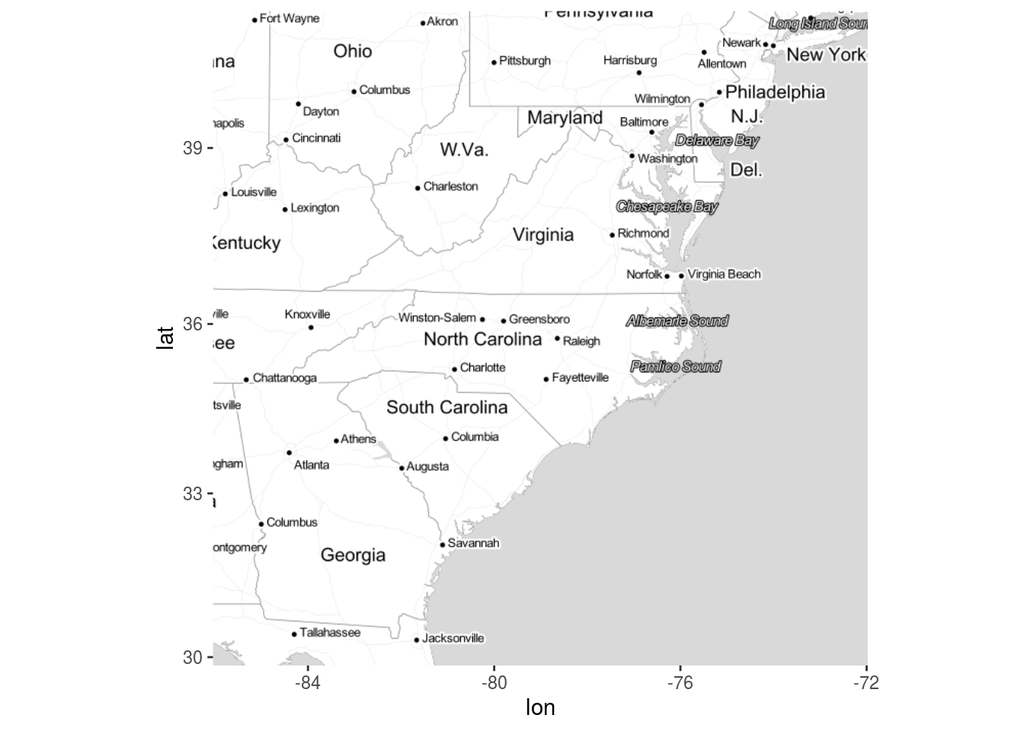

```r
nc <- get_map(location = 'North Carolina', zoom = 6, source = "stamen", maptype = "toner-lite")
ggmap(nc)
```

I created a map of North Carolina using the get_map function and I named the map nc.

### Alcohol Producers in California

```r
ca_plot <- ggmap(ca, base_layer = ggplot(ca_mapping_data, aes(x =lon, y = lat, size = count, color = type, label = city))) +
  geom_point(alpha = .5) +
  theme_void()
```

This plot, which I call ca_plot, shows the total number of producers by city in California. The size of the dot indicates the of the total number of producers in that city and the color of the dot indicates the type of producer.

### Alcohol Producers in North Carolina

```r
nc_plot <- ggmap(nc, base_layer = ggplot(nc_mapping_data, aes(x =lon, y = lat, size = count, color = type, label = city))) +
  geom_point(alpha = .5) +
  theme_void()
```

This plot, which I call nc_plot, is the same as ca_plot except it is for North Carolina.

### Side by Side Comparison of Alcohol Producers in California and North Carolina

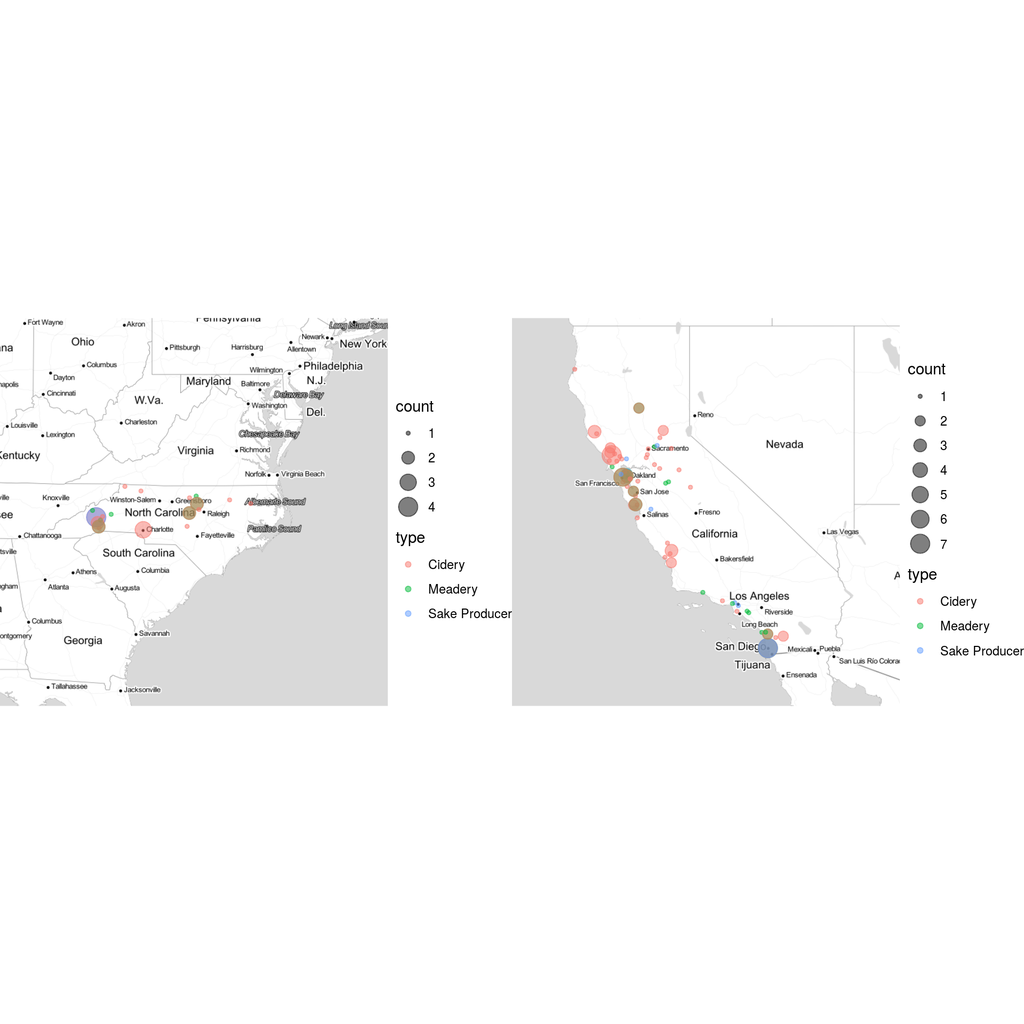

```r
grid.arrange(nc_plot, ca_plot, ncol = 2)
```

In this chunk, I use the grid.arrange() function to put ca_plot and nc_plot side by side.

# Question 7

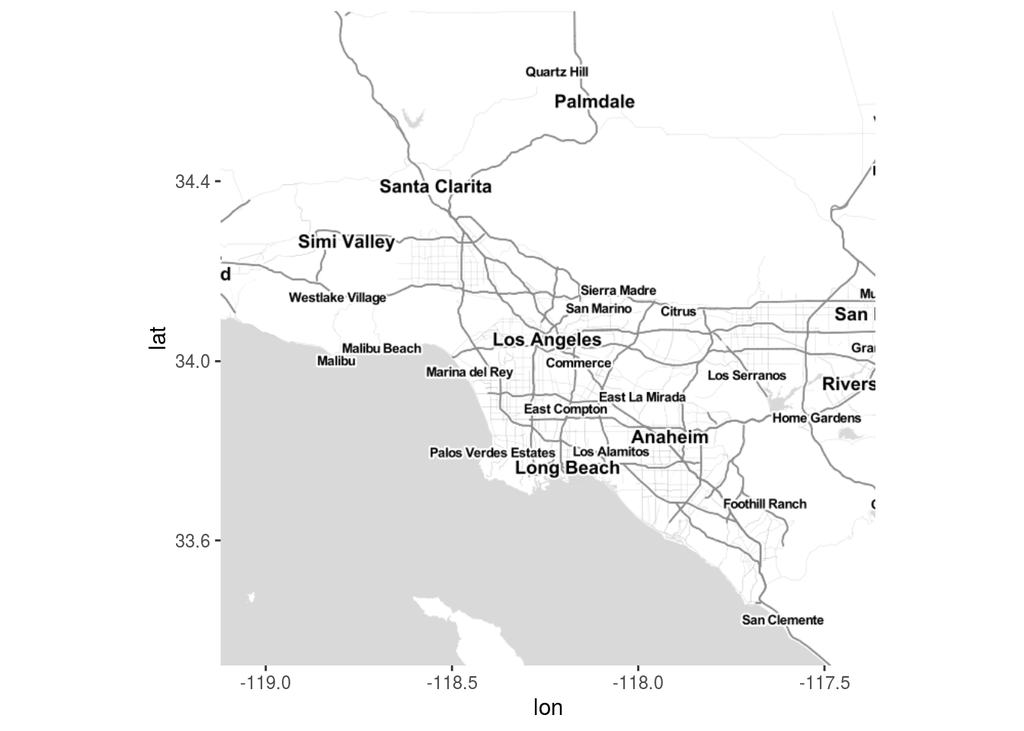

```r
la <- get_map(location = 'Los Angeles, California', zoom = 9, source = "stamen", maptype = "toner-lite")
ggmap(la)
```

I created a map of Los Angeles using the get_map function and I named the map la.

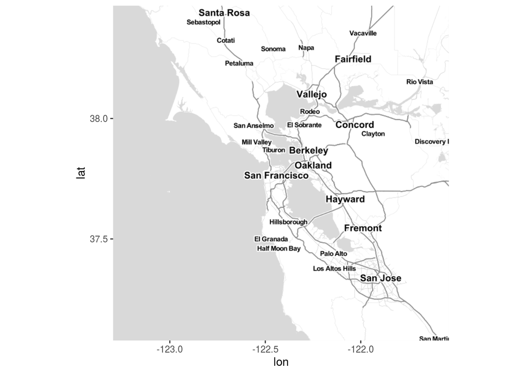

```r
sf <- get_map(location = 'San Francisco, California', zoom = 9, source = "stamen", maptype = "toner-lite")
ggmap(sf)
```

I created a map of San Francisco using the get_map function and I named the map sf.

```r
la_plot <- ggmap(la, base_layer = ggplot(ca_mapping_data, aes(x =lon, y = lat, size = count, color = type, label = city))) +
  geom_point(alpha = .5) +
  theme_void()
```

This plot, which I call la_plot, shows the total number of producers in Los Angeles. The size of the dot indicates the of the total number of producers in that area and the color of the dot indicates the type of producer.

```r
sf_plot <- ggmap(sf, base_layer = ggplot(ca_mapping_data, aes(x =lon, y = lat, size = count, color = type, label = city))) +
  geom_point(alpha = .5) +
  theme_void()
```

This plot, which I call sf_plot, is the same as ca_plot except it is for San Francisco.

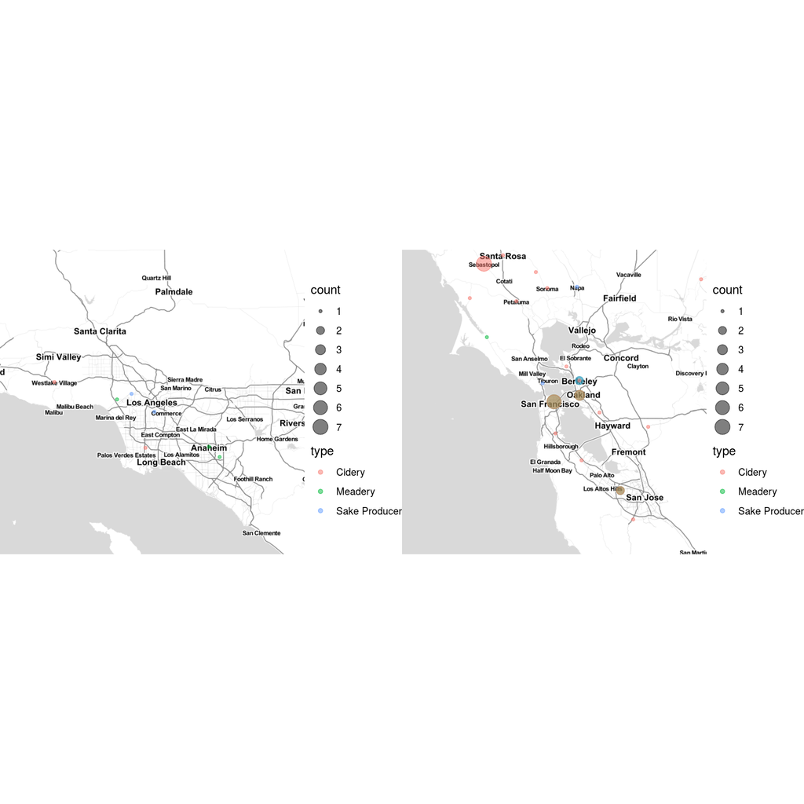

```r
grid.arrange(la_plot, sf_plot, ncol = 2)
```

In this chunk, I use the grid.arrange() function to put la_plot and sf_plot side by side.

# Project Log

1). Date: 4/5/2021 Problem: I was having trouble figuring out how to get the functions in questions 1 and 2 to work. Solution: I met with Professor Ballenger, who helped me to work through it logically.

2). Date: 4/6/2021 Problem: I was having trouble figuring out how to get the scrape_beverage_producer scrape through all of the urls for each state and create a dataframe for that state. Solution: I emailed Professor Ballenger and he recommended that I look back at the automation section of the programming slides. I did this and found that the map_df() funciton was the solution.

3). Date: 4/6/2021 Problem: I was trying to figure out how to add a column that has the state names to the North Carolina and California dataframes. Solution: I looked online and found a website that showed me the add_column() function. Here is the link: https://tibble.tidyverse.org/reference/add_column.html

4). Date: 4/7/2021 Problem: I was having trouble figuring out how to do the data wrangling for the North Carolina and California dataframes. I was also struggling a bit with the side by side geo-mapping. Solution: I met with Professor Ballenger and he recommended that I look back at slides 38 and 40 in the Tidyverse review slides. I did this and found that using group_by() and count = n() was the solution. I also remebered to use the grid.arrange() function for the side by side geo-mapping while talking with Professor Ballenger.

# Honor Pledge

On my honor, I have neither given nor received any unacknowledged aid on this assignment.

-Brennan Black